# Analysing trials - Workshop part 2

2021-11-17

## Hypertrophy and graded protein dose

- Read Haun et al. (Haun et al. 2018) and find the main purpose/aim/hypothesis of the study.
- How do they motivate their purpose/aim/hypothesis?
- What is the statistical test used test the main hypotheses?

## Make it simple!

Design an analysis of the data from Haun et al. (2018):

- Include only two time-points (T1 and T3)
- Select one measure of muscle hypertrophy
- Select a test for a null-hypothesis significance test
- Do your results correspond to what is found in Haun et al. (2018)?

## A possible solution

We will start by exploring the data, we will use the `VL` (vastus lateralis thickness) data to answer the question if protein supplementation affects training outcomes. Data exploration could mean that we plot the data and include information on groups etc.

The plot below shows the relationship between pre- and post-intervention values with groups indicated by different colors. Points above the line indicates that a participant has greater values after the intervention. Points below the identity line indicates that participants have a negative development pre- to post-intervention.

```r
library(exscidata); library(tidyverse)
```

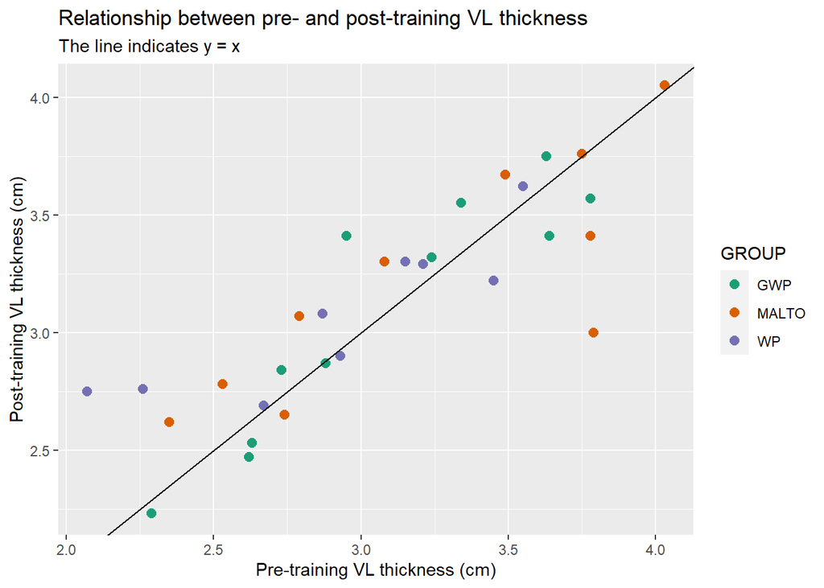

```r
data("hypertrophy")

# For plotting we will set a color scale
col_scale <- c("#1b9e77", "#d95f02", "#7570b3")





hypertrophy %>%
  select(PARTICIPANT, GROUP, VL_T1, VL_T3) %>%
  ggplot(aes(VL_T1, VL_T3, color = GROUP)) + geom_point(size = 2.5) +
  geom_abline(intercept = 0, slope = 1) +

  scale_color_manual(values = col_scale) +

  labs(title = "Relationship between pre- and post-training VL thickness",
       subtitle = "The line indicates y = x",
       x = "Pre-training VL thickness (cm)",
       y = "Post-training VL thickness (cm)")
```

A simple model would be an extension of the above plot. Accounting for the relationship between pre- and post-intervention values, what is the difference between groups at post-intervention. This question can be answered with an ANCOVA. We will start by fitting the model:

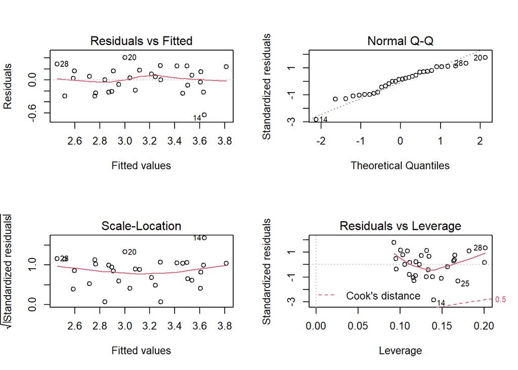

```r
# Save the data set
dat <- hypertrophy %>%
  select(PARTICIPANT, GROUP, VL_T1, VL_T3)

# Fit the model
m1 <- lm(VL_T3 ~ VL_T1 + GROUP, data = dat)


# Plot all diagniostic plots in a single plot
par(mfrow = c(2, 2))
plot(m1)
```

```r
par(mfrow = c(1,1)) # resets the plot window
```

The diagnostic plots shows no obvious patterns in the residual vs. fitted plots (left column), the residuals might be slightly deviating from a normal distribution (top right) and no data point falls outside the Cook’s distance indicating that no single data point influences the fit to large degree (bottom right).

We may now extract the model coefficients. We will start by plotting them in a graph.

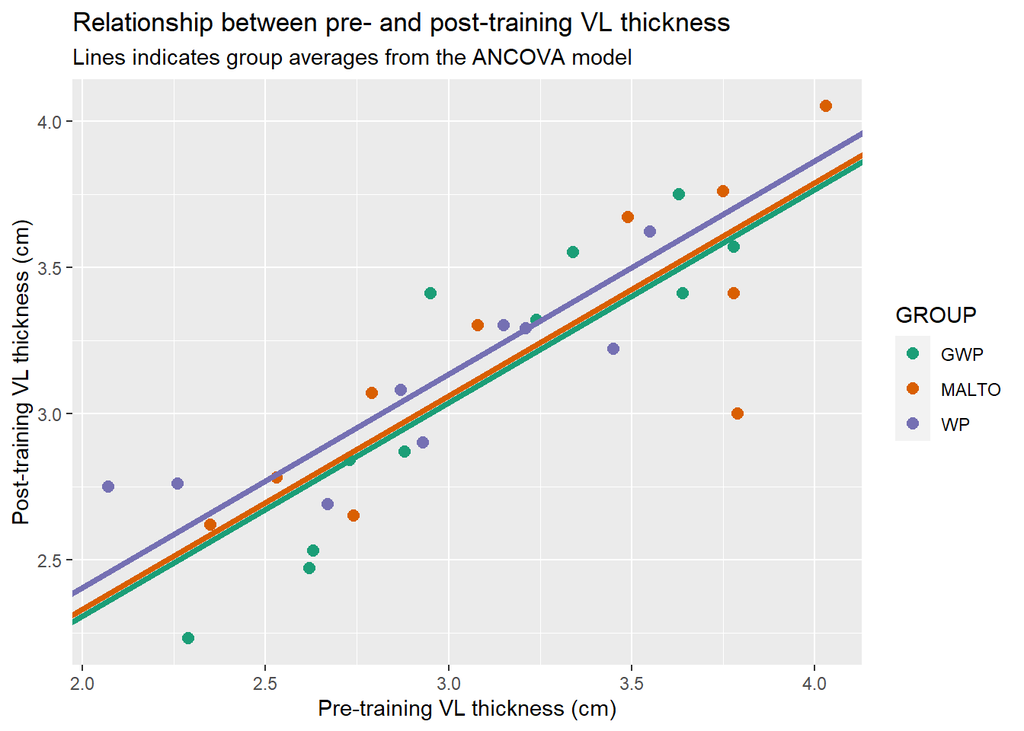

```r
hypertrophy %>%
  select(PARTICIPANT, GROUP, VL_T1, VL_T3) %>%
  ggplot(aes(VL_T1, VL_T3, color = GROUP)) + geom_point(size = 2.5) +

    scale_color_manual(values = col_scale) +

  geom_abline(intercept = coef(m1)[1], slope = coef(m1)[2], color = col_scale[1], size = 1.5) +
   geom_abline(intercept = coef(m1)[1] + coef(m1)[3] , slope = coef(m1)[2], color = col_scale[2], size = 1.5) +
   geom_abline(intercept = coef(m1)[1] + coef(m1)[4], slope = coef(m1)[2], color = col_scale[3], size = 1.5 ) +
  labs(title = "Relationship between pre- and post-training VL thickness",
       subtitle = "Lines indicates group averages from the ANCOVA model",
       x = "Pre-training VL thickness (cm)",
       y = "Post-training VL thickness (cm)")
```

Each line in the plot above indicate group averages in post scores given pre-intervention scores. The vertical distance between lines indicate the differences between groups.

The model

$$y = \beta_0 + \beta_1X_1 + \beta_2X_2 + \beta_3X_3$$
has an intercept $\beta_0$ that corresponds to the post-intervention values when all coefficients are set to 0 (all $X = 0$). The slope $\beta_1X_1$ is the pre-intervention values and $\beta_2X_2$ and $\beta_3X_3$ are group indicators ($X_2 = 1$ indicates `group = MALTO`, $X_3 = 1$ indicates `group = WP`) giving the differences between `MALTO` and `WP` to the reference level `GWP`.

Inspecting the summary gives supports what the figure already shows, that there are no great differences between groups in post-intervention values:

```r
summary(m1)
```

```
##
## Call:
## lm(formula = VL_T3 ~ VL_T1 + GROUP, data = dat)
##
## Residuals:
##      Min       1Q   Median       3Q      Max
## -0.63728 -0.20006  0.03602  0.16346  0.40851
##
## Coefficients:
##             Estimate Std. Error t value Pr(>|t|)
## (Intercept)  0.84974    0.27620   3.077  0.00488 **
## VL_T1        0.72940    0.08687   8.396 7.06e-09 ***
## GROUPMALTO   0.02309    0.10676   0.216  0.83046
## GROUPWP      0.09790    0.10969   0.892  0.38033
## ---
## Signif. codes:  0 '***' 0.001 '**' 0.01 '*' 0.05 '.' 0.1 ' ' 1
##
## Residual standard error: 0.2421 on 26 degrees of freedom
##   (1 observation deleted due to missingness)
## Multiple R-squared:  0.7379, Adjusted R-squared:  0.7076
## F-statistic:  24.4 on 3 and 26 DF,  p-value: 1.004e-07
```

Haun et al. (2018) used delta-scores (or change-scores) to anwer their question. Instead of modelling the post-values we could model the change. We will start by exploring the relationship between the baseline and change. We will then fit a model on change scores.

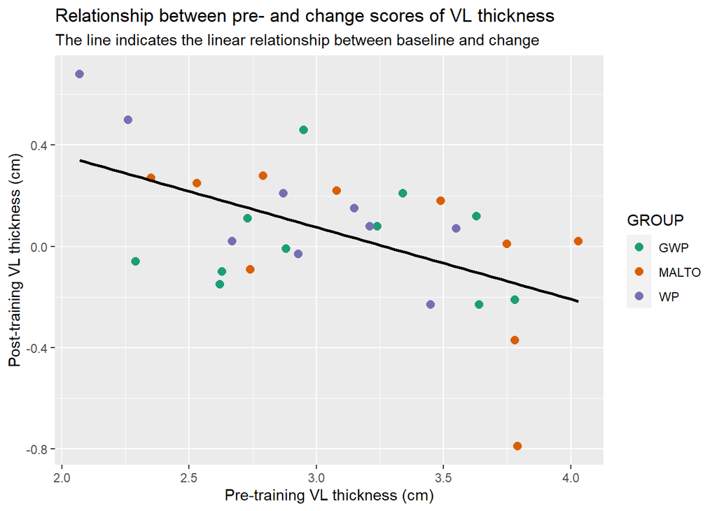

```r
hypertrophy %>%
  select(PARTICIPANT, GROUP, VL_T1, VL_T3) %>%
  mutate(change = VL_T3 - VL_T1) %>%
  ggplot(aes(VL_T1, change, color = GROUP)) + geom_point(size = 2.5) +
      scale_color_manual(values = col_scale) +
  geom_smooth(aes(color = NULL), method = "lm", se = FALSE, color = "black") +

  labs(title = "Relationship between pre- and change scores of VL thickness",
       subtitle = "The line indicates the linear relationship between baseline and change",
       x = "Pre-training VL thickness (cm)",
       y = "Post-training VL thickness (cm)")
```

The regression line indicates that there is a negative relationship between baseline and change score values. This is something we should consider when comparing groups. Again, an ANCOVA model will make a correction for this relationship. Any imbalance between groups at baseline will be accounted for by modelling the reliationship between baseline and change.

We will fit the model:

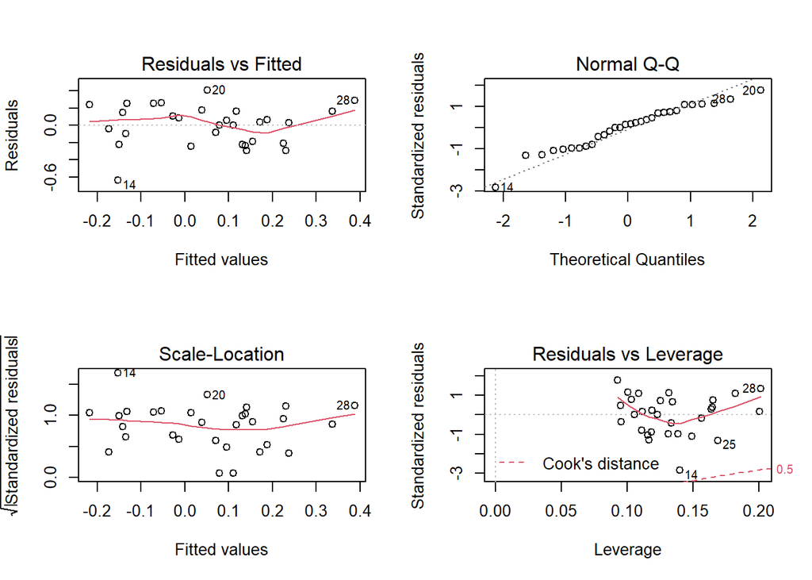

```r
dat2 <- hypertrophy %>%
  select(PARTICIPANT, GROUP, VL_T1, VL_T3) %>%
  mutate(change = VL_T3 - VL_T1)

m2 <- lm(change ~ VL_T1 + GROUP, data = dat2)


par(mfrow = c(2, 2))
plot(m2)
```

```r
par(mfrow = c(1, 1))
```

Inspecting the diagnostics plots gives us no reason for big concerns regarding the model fit (except maybe for the Q-Q plot). We may will proceed with the model summary. Like before we will plot the model estimates over the raw data.

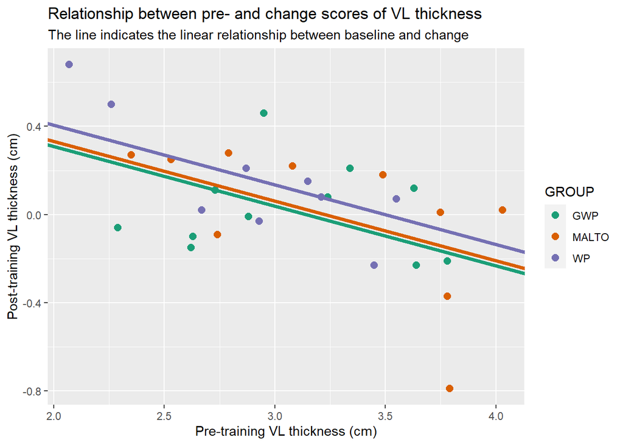

```r
hypertrophy %>%
  select(PARTICIPANT, GROUP, VL_T1, VL_T3) %>%
  mutate(change = VL_T3 - VL_T1) %>%
  ggplot(aes(VL_T1, change, color = GROUP)) + geom_point(size = 2.5) +

    scale_color_manual(values = col_scale) +

  geom_abline(intercept = coef(m2)[1], slope = coef(m2)[2], color = col_scale[1], size = 1.5) +
   geom_abline(intercept = coef(m2)[1] + coef(m2)[3] , slope = coef(m2)[2], color = col_scale[2], size = 1.5) +
   geom_abline(intercept = coef(m2)[1] + coef(m2)[4], slope = coef(m2)[2], color = col_scale[3], size = 1.5) +

  labs(title = "Relationship between pre- and change scores of VL thickness",
       subtitle = "The line indicates the linear relationship between baseline and change",
       x = "Pre-training VL thickness (cm)",
       y = "Post-training VL thickness (cm)")
```

Similarly to the model of raw post-intervention values, the vertical difference between groups are similar. Making tables of the two model indicates that the estimated differences between groups are the same irrespective if we modeled change scores or raw data.

```r
library(knitr)


bind_rows(broom::tidy(m1) %>%
  mutate(model = "Raw scores"),
  broom::tidy(m2) %>%
  mutate(model = "Change-scores")) %>%
  select(model, term:p.value) %>%
  kable(col.names = c("Model", "Coefficient", "Estimate", "SE", "t-value", "p-value"))
```

| Model | Coefficient | Estimate | SE | t-value | p-value |
| --- | --- | --- | --- | --- | --- |
| Raw scores | (Intercept) | 0.8497437 | 0.2762040 | 3.0765078 | 0.0048839 |
| Raw scores | VL_T1 | 0.7294047 | 0.0868730 | 8.3962152 | 0.0000000 |
| Raw scores | GROUPMALTO | 0.0230910 | 0.1067635 | 0.2162821 | 0.8304558 |
| Raw scores | GROUPWP | 0.0978979 | 0.1096930 | 0.8924715 | 0.3803263 |
| Change-scores | (Intercept) | 0.8497437 | 0.2762040 | 3.0765078 | 0.0048839 |
| Change-scores | VL_T1 | -0.2705953 | 0.0868730 | -3.1148369 | 0.0044456 |
| Change-scores | GROUPMALTO | 0.0230910 | 0.1067635 | 0.2162821 | 0.8304558 |
| Change-scores | GROUPWP | 0.0978979 | 0.1096930 | 0.8924715 | 0.3803263 |

**What model do you think is easiest to explain?**

## Reproducing the results from Haun et al. (2018)

Haun et al. (2018) used three time-points (T1, T2 and T3), for the three groups. In Figure 5 results from an ANCOVA on change scores is presented. Let’s see if we can replicate the results. We will start by recreating the lower panel of figure 5B. It turns out that the summary values from each of the group/time-point combinations correspond when complete cases are used.

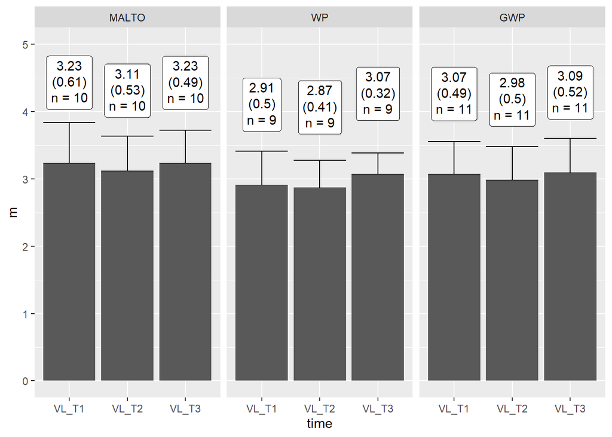

```r
library(ggtext) # used to get the plotting more accurate

hypertrophy %>%
  select(PARTICIPANT, GROUP, VL_T1, VL_T2, VL_T3) %>%
  filter(complete.cases(.)) %>%
  pivot_longer(names_to = "time", values_to = "thickness",
               cols = VL_T1:VL_T3) %>%
  group_by(time, GROUP) %>%
  summarise(m = mean(thickness, na.rm = TRUE),
            s = sd(thickness, na.rm = TRUE),
            n = n()) %>%
  mutate(sum_stat = paste0(round(m,2), "<br>(", round(s, 2), ")<br>n = ", n),
         GROUP = factor(GROUP, levels = c("MALTO", "WP", "GWP"))) %>%
  ggplot(aes(time, m)) +
  geom_errorbar(aes(ymin = m, ymax = m + s)) +
  geom_bar(stat = "identity") +

  geom_richtext(aes(label = sum_stat), nudge_y = 1.2) +

  facet_wrap(~ GROUP, ncol = 3) +
  scale_y_continuous(limits = c(0, 5))
```

The results of the ANCOVA model in Figure 5B indicates that both mid (T2) and (T3) values are used in the same model. The raw change score data is plotted in the upper panel of Figure 5B. We recreate the plot below.

```r
dat3 <- hypertrophy %>%
  select(PARTICIPANT, GROUP, VL_T1, VL_T2, VL_T3) %>%
  filter(complete.cases(.)) %>%
  mutate(VL_T1 = VL_T1,
         VL_T2 = VL_T2,
         VL_T3 = VL_T3,
         T2 = VL_T2 - VL_T1,
         T3 = VL_T3 - VL_T1,
         VL_T1 = VL_T1 - mean(VL_T1, na.rm = TRUE),
          GROUP = factor(GROUP, levels = c("MALTO", "WP", "GWP"))) %>%
  select(PARTICIPANT:VL_T1, T2, T3) %>%
  pivot_longer(names_to = "time", values_to = "change", cols = T2:T3) %>%
  print()
```

```
## # A tibble: 60 x 5
##    PARTICIPANT GROUP  VL_T1 time   change
##    <chr>       <fct>  <dbl> <chr>   <dbl>
##  1 MRV002      WP    -0.144 T2    -0.23
##  2 MRV002      WP    -0.144 T3    -0.0300
##  3 MRV003      GWP    0.266 T2     0
##  4 MRV003      GWP    0.266 T3     0.21
##  5 MRV004      GWP   -0.444 T2    -0.21
##  6 MRV004      GWP   -0.444 T3    -0.100
##  7 MRV005      MALTO  0.706 T2    -0.25
##  8 MRV005      MALTO  0.706 T3    -0.370
##  9 MRV006      WP     0.376 T2    -0.25
## 10 MRV006      WP     0.376 T3    -0.23
## # ... with 50 more rows
```

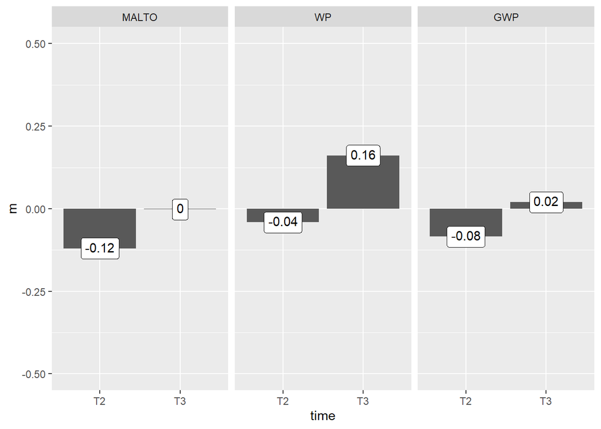

```r
dat3 %>%
  group_by(time, GROUP) %>%
  summarise(m = mean(change)) %>%
  ggplot(aes(time, m)) + geom_bar(stat = "identity") +
  facet_wrap(~ GROUP, ncol = 3) + scale_y_continuous(limits = c(-0.5, 0.5)) +
  geom_richtext(aes(label = round(m, 2)))
```

The model may be fitted using the `lmer` function from `lme4`. We do this since the data are correlated (as long as we use more than a single data point from each participant.)

```r
library(lmerTest); library(emmeans)
```

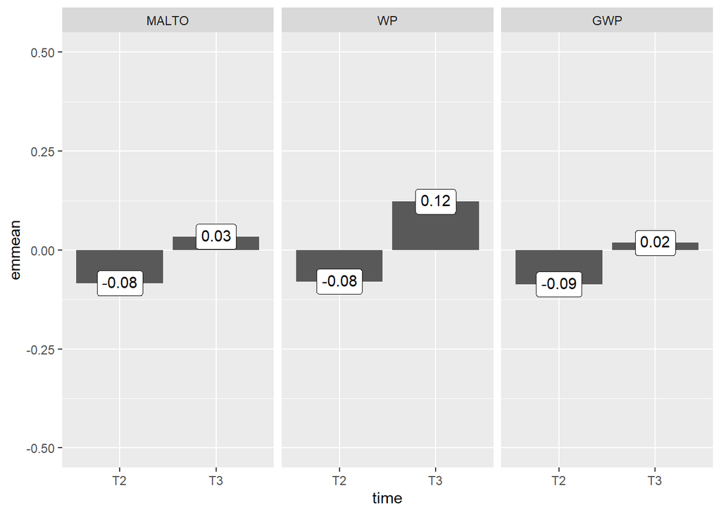

```r
# fit the model
m3 <- lmer(change ~  VL_T1 + (time * GROUP) + (1|PARTICIPANT), data = dat3)


# calculate estimated marginal means (corrected means)
emmeans(m3, specs = ~ GROUP|time) %>%
  data.frame() %>%
  ggplot(aes(time, emmean)) + geom_bar(stat = "identity") +
  facet_wrap(~ GROUP, ncol = 3) + scale_y_continuous(limits = c(-0.5, 0.5)) +
  geom_richtext(aes(label = round(emmean, 2)))
```

The ANOVA table do not correspond to the published values:

```r
library(knitr)

# get the global p-values
data.frame(anova(m3)) %>%
  mutate(term = row.names(.)) %>%
  select(term, Pr..F.) %>%
  kable(col.names = c("Term", "P-value"))
```

|  | Term | P-value |
| --- | --- | --- |
| VL_T1 | VL_T1 | 0.0056993 |
| time | time | 0.0001592 |
| GROUP | GROUP | 0.8323090 |
| time:GROUP | time:GROUP | 0.4346350 |

## An alternative model - the mixed effects model

```r
dat4 <- hypertrophy %>%
  select(PARTICIPANT, GROUP, VL_T1, VL_T2, VL_T3) %>%

  pivot_longer(names_to = "time", values_to = "change", cols = VL_T1:VL_T3) %>%
  print()
```

```
## # A tibble: 93 x 4
##    PARTICIPANT GROUP time  change
##    <chr>       <chr> <chr>  <dbl>
##  1 MRV001      WP    VL_T1  NA
##  2 MRV001      WP    VL_T2   2.99
##  3 MRV001      WP    VL_T3   3.45
##  4 MRV002      WP    VL_T1   2.93
##  5 MRV002      WP    VL_T2   2.7
##  6 MRV002      WP    VL_T3   2.9
##  7 MRV003      GWP   VL_T1   3.34
##  8 MRV003      GWP   VL_T2   3.34
##  9 MRV003      GWP   VL_T3   3.55
## 10 MRV004      GWP   VL_T1   2.63
## # ... with 83 more rows
```

```r
m4 <- lmer(log(change) ~ time * GROUP + (1|PARTICIPANT), data = dat4)

anova(m4)
```

```
## Type III Analysis of Variance Table with Satterthwaite's method
##              Sum Sq   Mean Sq NumDF  DenDF F value   Pr(>F)
## time       0.041049 0.0205245     2 55.070  6.6922 0.002502 **
## GROUP      0.003009 0.0015043     2 28.031  0.4905 0.617482
## time:GROUP 0.013514 0.0033786     4 55.068  1.1016 0.365063
## ---
## Signif. codes:  0 '***' 0.001 '**' 0.01 '*' 0.05 '.' 0.1 ' ' 1
```

```r
summary(m4)
```

```
## Linear mixed model fit by REML. t-tests use Satterthwaite's method [
## lmerModLmerTest]
## Formula: log(change) ~ time * GROUP + (1 | PARTICIPANT)
##    Data: dat4
##
## REML criterion at convergence: -135.1
##
## Scaled residuals:
##      Min       1Q   Median       3Q      Max
## -2.34997 -0.46998  0.06295  0.57528  2.39646
##
## Random effects:
##  Groups      Name        Variance Std.Dev.
##  PARTICIPANT (Intercept) 0.023651 0.15379
##  Residual                0.003067 0.05538
## Number of obs: 92, groups:  PARTICIPANT, 31
##
## Fixed effects:
##                        Estimate Std. Error         df t value Pr(>|t|)
## (Intercept)           1.1086447  0.0492840 32.7045867  22.495   <2e-16 ***
## timeVL_T2            -0.0292702  0.0236140 55.0293931  -1.240   0.2204
## timeVL_T3             0.0047384  0.0236140 55.0293931   0.201   0.8417
## GROUPMALTO            0.0482631  0.0714192 32.7045866   0.676   0.5039
## GROUPWP              -0.0478748  0.0717690 33.3045074  -0.667   0.5093
## timeVL_T2:GROUPMALTO -0.0055593  0.0342200 55.0293931  -0.162   0.8715
## timeVL_T3:GROUPMALTO  0.0007976  0.0342200 55.0293931   0.023   0.9815
## timeVL_T2:GROUPWP     0.0168407  0.0349440 55.1210125   0.482   0.6318
## timeVL_T3:GROUPWP     0.0629970  0.0349440 55.1210125   1.803   0.0769 .
## ---
## Signif. codes:  0 '***' 0.001 '**' 0.01 '*' 0.05 '.' 0.1 ' ' 1
##
## Correlation of Fixed Effects:
##               (Intr) tmVL_T2 tmVL_T3 GROUPM GROUPW tVL_T2:GROUPM tVL_T3:GROUPM
## timeVL_T2     -0.240
## timeVL_T3     -0.240  0.500
## GROUPMALTO    -0.690  0.165   0.165
## GROUPWP       -0.687  0.165   0.165   0.474
## tVL_T2:GROUPM  0.165 -0.690  -0.345  -0.240 -0.114
## tVL_T3:GROUPM  0.165 -0.345  -0.690  -0.240 -0.114  0.500
## tVL_T2:GROUPW  0.162 -0.676  -0.338  -0.112 -0.253  0.466         0.233
## tVL_T3:GROUPW  0.162 -0.338  -0.676  -0.112 -0.253  0.233         0.466
##               tVL_T2:GROUPW
## timeVL_T2
## timeVL_T3
## GROUPMALTO
## GROUPWP
## tVL_T2:GROUPM
## tVL_T3:GROUPM
## tVL_T2:GROUPW
## tVL_T3:GROUPW  0.521
```

# References

Haun, C. T., C. G. Vann, C. B. Mobley, P. A. Roberson, S. C. Osburn, H. M. Holmes, P. M. Mumford, et al. 2018. “Effects of Graded Whey Supplementation During Extreme-Volume Resistance Training.” *Front Nutr* 5: 84. https://doi.org/10.3389/fnut.2018.00084.